# p8105_hw2_pm3148

Pooja Mukund

10/6/2021

#### Load relevant packages

```r
library(tidyverse)
library(readxl)
```

## Problem 1

#### Import Mr. Trash Wheel Dataset

```r
trash_wheel = read_excel("./data/Trash-Wheel-Collection-Totals-7-2020-2.xlsx",
                         range="A2:N534")

str(trash_wheel)
```

```
## tibble [532 × 14] (S3: tbl_df/tbl/data.frame)
##  $ Dumpster            : num [1:532] 1 2 3 4 5 6 7 8 NA 9 ...
##  $ Month               : chr [1:532] "May" "May" "May" "May" ...
##  $ Year                : num [1:532] 2014 2014 2014 2014 2014 ...
##  $ Date                : POSIXct[1:532], format: "2014-05-16" "2014-05-16" ...
##  $ Weight (tons)       : num [1:532] 4.31 2.74 3.45 3.1 4.06 ...
##  $ Volume (cubic yards): num [1:532] 18 13 15 15 18 13 8 16 116 14 ...
##  $ Plastic Bottles     : num [1:532] 1450 1120 2450 2380 980 1430 910 3580 14300 2400 ...
##  $ Polystyrene         : num [1:532] 1820 1030 3100 2730 870 ...
##  $ Cigarette Butts     : num [1:532] 126000 91000 105000 100000 120000 90000 56000 112000 800000 98000 ...
##  $ Glass Bottles       : num [1:532] 72 42 50 52 72 46 32 58 424 49 ...
##  $ Grocery Bags        : num [1:532] 584 496 1080 896 368 ...
##  $ Chip Bags           : num [1:532] 1162 874 2032 1971 753 ...
##  $ Sports Balls        : num [1:532] 7.2 5.2 6 6 7.2 5.2 3.2 6.4 46.4 5.6 ...
##  $ Homes Powered*      : num [1:532] 0 0 0 0 0 0 0 0 0 0 ...
```

```r
trash_wheel<- trash_wheel %>%
   janitor::clean_names()

trash_wheel_na_clean<- trash_wheel%>%
  drop_na(dumpster)
```

```r
trash_wheel_col <- select(trash_wheel_na_clean)

trash_wheel_final<- trash_wheel_na_clean%>%
  mutate(sports_ball_rounded = round(sports_balls, 0))

#Find median number of sports balls in 2019
trash_wheel_final%>%
  filter(year ==2019)%>%
  summarise(median=median(sports_ball_rounded))
```

```
## # A tibble: 1 × 1
##   median
##    <dbl>
## 1      9
```

#### Explanation of Trash Wheel Data:

The Mr. Trash Wheel data set has 453 observations and 15 columns after cleaning the data according to instructions. The data set includes the following variables: dumpster, month, year, date, weight_tons, volume_cubic_yards, plastic_bottles, polystyrene, cigarette_butts, glass_bottles, grocery_bags, chip_bags, sports_balls, homes_powered, sports_ball_rounded. The median number of sports balls in the year 2019 is 9.

```r
precip_2019<- read_excel("./data/Trash-Wheel-Collection-Totals-7-2020-2.xlsx", 6, skip=1)
precip_2018<-read_excel("./data/Trash-Wheel-Collection-Totals-7-2020-2.xlsx", 7, skip=1)

head(precip_2019)
```

```
## # A tibble: 6 × 2
##   Month Total
##   <dbl> <dbl>
## 1     1  3.1
## 2     2  3.64
## 3     3  4.47
## 4     4  1.46
## 5     5  3.58
## 6     6  0.42
```

```r
precip_2019_tidy<- precip_2019%>%
  janitor::clean_names()%>%
  mutate(year = 2019)%>%
  drop_na(month)%>%
  drop_na(total)

precip_2018_tidy<-precip_2018%>%
  janitor::clean_names()%>%
  mutate(year = 2018)%>%
  drop_na(month)%>%
  drop_na(total)

precip_2019_tidy
```

```
## # A tibble: 12 × 3
##    month total  year
##    <dbl> <dbl> <dbl>
##  1     1  3.1   2019
##  2     2  3.64  2019
##  3     3  4.47  2019
##  4     4  1.46  2019
##  5     5  3.58  2019
##  6     6  0.42  2019
##  7     7  3.85  2019
##  8     8  2.39  2019
##  9     9  0.16  2019
## 10    10  5.45  2019
## 11    11  1.86  2019
## 12    12  3.57  2019
```

```r
precip_2018_tidy
```

```
## # A tibble: 12 × 3
##    month total  year
##    <dbl> <dbl> <dbl>
##  1     1  0.94  2018
##  2     2  4.8   2018
##  3     3  2.69  2018
##  4     4  4.69  2018
##  5     5  9.27  2018
##  6     6  4.77  2018
##  7     7 10.2   2018
##  8     8  6.45  2018
##  9     9 10.5   2018
## 10    10  2.12  2018
## 11    11  7.82  2018
## 12    12  6.11  2018
```

```r
precip_combined<- bind_rows(precip_2019_tidy, precip_2018_tidy)%>%
  mutate(month = month.name[month])

#Total Precipitation in 2018
precip_combined%>%
  filter(year==2018)%>%
  summarise(sum(total))
```

```
## # A tibble: 1 × 1
##   `sum(total)`
##          <dbl>
## 1         70.3
```

## Problem 2

#### pols-month data cleaning

```r
pols_month<- read_csv("data/pols-month.csv")
head(pols_month)
```

```
## # A tibble: 6 × 9
##   mon        prez_gop gov_gop sen_gop rep_gop prez_dem gov_dem sen_dem rep_dem
##   <date>        <dbl>   <dbl>   <dbl>   <dbl>    <dbl>   <dbl>   <dbl>   <dbl>
## 1 1947-01-15        0      23      51     253        1      23      45     198
## 2 1947-02-15        0      23      51     253        1      23      45     198
## 3 1947-03-15        0      23      51     253        1      23      45     198
## 4 1947-04-15        0      23      51     253        1      23      45     198
## 5 1947-05-15        0      23      51     253        1      23      45     198
## 6 1947-06-15        0      23      51     253        1      23      45     198
```

```r
pols_month_tidy<-pols_month%>%
  separate(mon, into = c("year", "month", "day"), sep="-")%>%
  mutate(
    month = replace(month, month=="01", "January"),
    month = replace(month, month=="02", "February"),
    month = replace(month, month=="03", "March"),
    month = replace(month, month=="04", "April"),
    month = replace(month, month=="05", "May"),
    month = replace(month, month=="06", "June"),
    month = replace(month, month=="07", "July"),
    month = replace(month, month=="08", "August"),
    month = replace(month, month=="09", "September"),
    month = replace(month, month=="10", "October"),
    month = replace(month, month=="11", "November"),
    month = replace(month, month=="12", "December"),
    pres = if_else(prez_dem>0, "dem", "gop"))%>%
  select(-prez_dem, -c(prez_dem, prez_gop, day))
```

#### snp data cleaning

```r
snp<- read_csv("data/snp.csv")
head(snp)
```

```
## # A tibble: 6 × 2
##   date   close
##   <chr>  <dbl>
## 1 7/1/15 2080.
## 2 6/1/15 2063.
## 3 5/1/15 2107.
## 4 4/1/15 2086.
## 5 3/2/15 2068.
## 6 2/2/15 2104.
```

```r
snp_tidy<-snp%>%
  separate(date, into = c("month", "day", "year"), sep="/")%>%
  mutate(
    month = replace(month, month=="1", "January"),
    month = replace(month, month=="2", "February"),
    month = replace(month, month=="3", "March"),
    month = replace(month, month=="4", "April"),
    month = replace(month, month=="5", "May"),
    month = replace(month, month=="6", "June"),
    month = replace(month, month=="7", "July"),
    month = replace(month, month=="8", "August"),
    month = replace(month, month=="9", "September"),
    month = replace(month, month=="10", "October"),
    month = replace(month, month=="11", "November"),
    month = replace(month, month=="12", "December"),
    year_num = as.numeric(year),
    year_clean = ifelse(year_num>21, 1900+year_num, 2000+year_num),
    year = as.character(year_clean)
  )%>%
  select(year, month, close )
```

```r
unemployment<- read_csv("data/unemployment.csv")
head(unemployment)
```

```
## # A tibble: 6 × 13
##    Year   Jan   Feb   Mar   Apr   May   Jun   Jul   Aug   Sep   Oct   Nov   Dec
##   <dbl> <dbl> <dbl> <dbl> <dbl> <dbl> <dbl> <dbl> <dbl> <dbl> <dbl> <dbl> <dbl>
## 1  1948   3.4   3.8   4     3.9   3.5   3.6   3.6   3.9   3.8   3.7   3.8   4
## 2  1949   4.3   4.7   5     5.3   6.1   6.2   6.7   6.8   6.6   7.9   6.4   6.6
## 3  1950   6.5   6.4   6.3   5.8   5.5   5.4   5     4.5   4.4   4.2   4.2   4.3
## 4  1951   3.7   3.4   3.4   3.1   3     3.2   3.1   3.1   3.3   3.5   3.5   3.1
## 5  1952   3.2   3.1   2.9   2.9   3     3     3.2   3.4   3.1   3     2.8   2.7
## 6  1953   2.9   2.6   2.6   2.7   2.5   2.5   2.6   2.7   2.9   3.1   3.5   4.5
```

#### unemployment data cleaning

```r
unemployment_tidy_data <-
  unemployment%>%
  pivot_longer(!Year, names_to = "month", values_to = "unemployment_percentage")%>%
  mutate(
    Year = as.character(Year),
    month = replace(month, month=="Jan", "January"),
    month = replace(month, month=="Feb", "February"),
    month = replace(month, month=="Mar", "March"),
    month = replace(month, month=="Apr", "April"),
    month = replace(month, month=="May", "May"),
    month = replace(month, month=="Jun", "June"),
    month = replace(month, month=="Jul", "July"),
    month = replace(month, month=="Aug", "August"),
    month = replace(month, month=="Sep", "September"),
    month = replace(month, month=="Oct", "October"),
    month = replace(month, month=="Nov", "November"),
    month = replace(month, month=="Dec", "December"))%>%
  janitor::clean_names()
head(unemployment_tidy_data)
```

```
## # A tibble: 6 × 3
##   year  month    unemployment_percentage
##   <chr> <chr>                      <dbl>
## 1 1948  January                      3.4
## 2 1948  February                     3.8
## 3 1948  March                        4
## 4 1948  April                        3.9
## 5 1948  May                          3.5
## 6 1948  June                         3.6
```

```r
#Join pols_month_tidy with snp_tidy
joined_df = left_join(pols_month_tidy, snp_tidy, by = c("year", "month"))
#Join above data frame to unemployment
joined_df_full = left_join(joined_df, unemployment_tidy_data, by = c("year", "month"))
joined_df_full
```

```
## # A tibble: 822 × 11
##    year  month     gov_gop sen_gop rep_gop gov_dem sen_dem rep_dem pres  close
##    <chr> <chr>       <dbl>   <dbl>   <dbl>   <dbl>   <dbl>   <dbl> <chr> <dbl>
##  1 1947  January        23      51     253      23      45     198 dem      NA
##  2 1947  February       23      51     253      23      45     198 dem      NA
##  3 1947  March          23      51     253      23      45     198 dem      NA
##  4 1947  April          23      51     253      23      45     198 dem      NA
##  5 1947  May            23      51     253      23      45     198 dem      NA
##  6 1947  June           23      51     253      23      45     198 dem      NA
##  7 1947  July           23      51     253      23      45     198 dem      NA
##  8 1947  August         23      51     253      23      45     198 dem      NA
##  9 1947  September      23      51     253      23      45     198 dem      NA
## 10 1947  October        23      51     253      23      45     198 dem      NA
## # … with 812 more rows, and 1 more variable: unemployment_percentage <dbl>
```

```r
joined_df_full%>%
  summarise(range = range(as.numeric(year)))
```

```
## # A tibble: 2 × 1
##   range
##   <dbl>
## 1  1947
## 2  2015
```

#### Explanation of Joined Five Thirty Eight Data:

The combined Five Thirty Eight data set has 822 observations and 11 columns after cleaning the data according to instructions. The data set includes the following variables: year, month, gov_gop, sen_gop, rep_gop, gov_dem, sen_dem, rep_dem, pres, close, unemployment_percentage. The combined data set combines pols_month, snp, and unemployment data sets. “pols-month” contains 822 observations of 9 variables related to the number of national politicians who are democratic or republican at any given time. “snp” contains date and close, the closing values the S&P stock index on the associated date. “unemployment” contains the percentage of unemployment at that specific date. The range of years represented in the data set is 1947-2015.

## Problem 3

```r
baby_names<-read_csv("data/Popular_Baby_names.csv")
head(baby_names)
```

```
## # A tibble: 6 × 6
##   `Year of Birth` Gender Ethnicity               `Child's First Nam… Count  Rank
##             <dbl> <chr>  <chr>                   <chr>               <dbl> <dbl>
## 1            2016 FEMALE ASIAN AND PACIFIC ISLA… Olivia                172     1
## 2            2016 FEMALE ASIAN AND PACIFIC ISLA… Chloe                 112     2
## 3            2016 FEMALE ASIAN AND PACIFIC ISLA… Sophia                104     3
## 4            2016 FEMALE ASIAN AND PACIFIC ISLA… Emily                  99     4
## 5            2016 FEMALE ASIAN AND PACIFIC ISLA… Emma                   99     4
## 6            2016 FEMALE ASIAN AND PACIFIC ISLA… Mia                    79     5
```

```r
baby_names%>%
  janitor::clean_names()%>%
  distinct(ethnicity)
```

```
## # A tibble: 7 × 1
##   ethnicity
##   <chr>
## 1 ASIAN AND PACIFIC ISLANDER
## 2 BLACK NON HISPANIC
## 3 HISPANIC
## 4 WHITE NON HISPANIC
## 5 ASIAN AND PACI
## 6 BLACK NON HISP
## 7 WHITE NON HISP
```

```r
baby_names%>%
  janitor::clean_names()%>%
  distinct(gender)
```

```
## # A tibble: 2 × 1
##   gender
##   <chr>
## 1 FEMALE
## 2 MALE
```

```r
baby_names%>%
  janitor::clean_names()%>%
  distinct(childs_first_name)
```

```
## # A tibble: 3,021 × 1
##    childs_first_name
##    <chr>
##  1 Olivia
##  2 Chloe
##  3 Sophia
##  4 Emily
##  5 Emma
##  6 Mia
##  7 Charlotte
##  8 Sarah
##  9 Isabella
## 10 Hannah
## # … with 3,011 more rows
```

```r
baby_names%>%
  janitor::clean_names()%>%
  distinct(year_of_birth)
```

```
## # A tibble: 6 × 1
##   year_of_birth
##           <dbl>
## 1          2016
## 2          2015
## 3          2014
## 4          2013
## 5          2012
## 6          2011
```

```r
#Two ways of Asian and Pacific Islander being written and multiple ways of black non-Hispanic, and white non-Hispanic being written. Gender and first name variables look tidy already.

baby_names_tidy<- baby_names%>%
  janitor::clean_names()%>%
  mutate(
    childs_first_name = str_to_sentence(childs_first_name),
    ethnicity = replace(ethnicity, ethnicity=="ASIAN AND PACI", "ASIAN AND PACIFIC ISLANDER"),
    ethnicity = replace(ethnicity, ethnicity=="BLACK NON HISP", "BLACK NON HISPANIC"),
    ethnicity = replace(ethnicity, ethnicity=="WHITE NON HISP", "WHITE NON HISPANIC")
  )%>%
  distinct()

baby_names_tidy%>%
  filter(childs_first_name=="Olivia")%>%
  select(-count)%>%
  pivot_wider(
  names_from = "year_of_birth",
  values_from = rank)%>%
  select(childs_first_name, gender, ethnicity, "2011", "2012", "2013", "2014", "2015", "2016")%>%
knitr::kable(caption= "Rank in Popularity of the female baby name Olivia over time")
```

Rank in Popularity of the female baby name Olivia over time

| childs_first_name | gender | ethnicity | 2011 | 2012 | 2013 | 2014 | 2015 | 2016 |
| --- | --- | --- | --- | --- | --- | --- | --- | --- |
| Olivia | FEMALE | ASIAN AND PACIFIC ISLANDER | 4 | 3 | 3 | 1 | 1 | 1 |
| Olivia | FEMALE | BLACK NON HISPANIC | 10 | 8 | 6 | 8 | 4 | 8 |
| Olivia | FEMALE | HISPANIC | 18 | 22 | 22 | 16 | 16 | 13 |
| Olivia | FEMALE | WHITE NON HISPANIC | 2 | 4 | 1 | 1 | 1 | 1 |

```r
baby_names_tidy%>%
  filter(childs_first_name=="Ethan" & gender=="MALE")%>%
  select(-count)%>%
  pivot_wider(
  names_from = "year_of_birth",
  values_from = "rank")%>%
  select(childs_first_name, gender, ethnicity, "2011", "2012", "2013", "2014", "2015", "2016")%>%
knitr::kable(caption= "Rank in Popularity of the male baby name Ethan over time")
```

Rank in Popularity of the male baby name Ethan over time

| childs_first_name | gender | ethnicity | 2011 | 2012 | 2013 | 2014 | 2015 | 2016 |
| --- | --- | --- | --- | --- | --- | --- | --- | --- |
| Ethan | MALE | ASIAN AND PACIFIC ISLANDER | 1 | 2 | 2 | 2 | 2 | 1 |
| Ethan | MALE | BLACK NON HISPANIC | 6 | 3 | 1 | 1 | 5 | 5 |
| Ethan | MALE | HISPANIC | 6 | 4 | 5 | 5 | 3 | 7 |
| Ethan | MALE | WHITE NON HISPANIC | 26 | 21 | 23 | 18 | 19 | 20 |

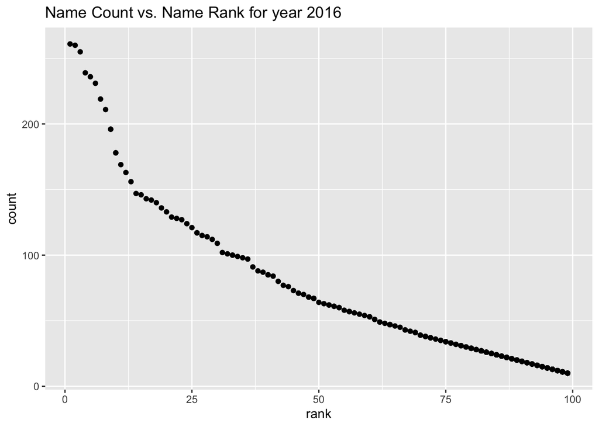

```r
baby_names_tidy%>%
  filter(gender=="MALE" & ethnicity=="WHITE NON HISPANIC" & year_of_birth==2016)%>%
  ggplot(aes(x=rank, y = count))+geom_point()+labs(title = "Name Count vs. Name Rank for year 2016")
```